# Assignment 1

# I. Regression

Welcome dear Reader, The first snow has already fallen, thus it is better to just stay inside, get comfortable in a cozy sofa and dive deep into the heart warming world of data science. In the following, first part of this assignment I will present four (three random forest and one spline) regression models to you. I hope you'll like them! We will use the "California Housing Prices" dataset from the `sklearn.datasets` module. It contains 20,640 observations drawn from the 1990 U.S. Census for the state of California. The variables are the following:

| Variable | Description |
| --- | --- |
| longitude | A measure of how far west a house is; a more negative value is farther west |
| latitude | A measure of how far north a house is; a higher value is farther north |
| housingMedianAge | Median age of a house within a block; a lower number is a newer building |
| totalRooms | Total number of rooms within a block |
| totalBedrooms | Total number of bedrooms within a blockawsd |
| population | Total number of people residing within a block |
| households | Total number of households, a group of people residing within a home unit, for a block |
| medIncome | Median income for households within a block of houses (measured in tens of thousands of US Dollars) |
| medHouseVal | Median house value for households within a block (measured in US Dollars). This will be our target value. |

### 1. Exploratory data analysis

Let's take a look at the first few rows of our dataset. We can see that all variables are numeric.

```python
from sklearn.datasets import fetch_california_housing;
from sklearn.model_selection import train_test_split;
from sklearn.preprocessing import StandardScaler;
from sklearn.metrics import mean_squared_error, r2_score;
from sklearn.linear_model import LinearRegression;

import numpy as np;
import pandas as pd;
import matplotlib.pyplot as plt;
import seaborn as sns;
import warnings;
# Settings the warnings to be ignored
#warnings.filterwarnings('ignore') ;


# Load the dataset
california_housing = fetch_california_housing(as_frame=True);
df = california_housing.frame;
```

```python
df.head()
```

|  | MedInc | HouseAge | AveRooms | AveBedrms | Population | AveOccup | Latitude | Longitude | MedHouseVal |
| --- | --- | --- | --- | --- | --- | --- | --- | --- | --- |
| 0 | 8.3252 | 41.0 | 6.984127 | 1.023810 | 322.0 | 2.555556 | 37.88 | -122.23 | 4.526 |
| 1 | 8.3014 | 21.0 | 6.238137 | 0.971880 | 2401.0 | 2.109842 | 37.86 | -122.22 | 3.585 |
| 2 | 7.2574 | 52.0 | 8.288136 | 1.073446 | 496.0 | 2.802260 | 37.85 | -122.24 | 3.521 |
| 3 | 5.6431 | 52.0 | 5.817352 | 1.073059 | 558.0 | 2.547945 | 37.85 | -122.25 | 3.413 |
| 4 | 3.8462 | 52.0 | 6.281853 | 1.081081 | 565.0 | 2.181467 | 37.85 | -122.25 | 3.422 |

If we use the describe function we can get some more information about the individual variables. The most obvious finding is that we will have huge problems with the outliers in our dataset. The upper 25% contains quite huge outliers when we examine the median income, the population, the average occupancy or our target variable, the median house value. This has the potential to seriously harm our models, if they are not highly correlated either with each other or with another variable. It could also mean that we have a lack of adequate training data.

```python
print(df.describe())
```

```
             MedInc      HouseAge      AveRooms     AveBedrms    Population  \
count  20640.000000  20640.000000  20640.000000  20640.000000  20640.000000
mean       3.870671     28.639486      5.429000      1.096675   1425.476744
std        1.899822     12.585558      2.474173      0.473911   1132.462122
min        0.499900      1.000000      0.846154      0.333333      3.000000
25%        2.563400     18.000000      4.440716      1.006079    787.000000
50%        3.534800     29.000000      5.229129      1.048780   1166.000000
75%        4.743250     37.000000      6.052381      1.099526   1725.000000
max       15.000100     52.000000    141.909091     34.066667  35682.000000

           AveOccup      Latitude     Longitude   MedHouseVal
count  20640.000000  20640.000000  20640.000000  20640.000000
mean       3.070655     35.631861   -119.569704      2.068558
std       10.386050      2.135952      2.003532      1.153956
min        0.692308     32.540000   -124.350000      0.149990
25%        2.429741     33.930000   -121.800000      1.196000
50%        2.818116     34.260000   -118.490000      1.797000
75%        3.282261     37.710000   -118.010000      2.647250
max     1243.333333     41.950000   -114.310000      5.000010
```

```python
california_housing = fetch_california_housing()
data = pd.DataFrame(data=np.c_[california_housing.data, california_housing.target],
                    columns=california_housing.feature_names + ['target'])
```

Since we are working with geospatial data, it may be useful to plot them on a map as well. The two main hubspots of the region (Los Angeles and San Francisco) are clearly visible, the highly valued real estates are mostly centered in these two regions.

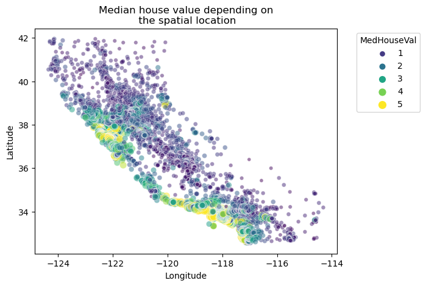

```python
#Map
sns.scatterplot(data = df, x = "Longitude", y = "Latitude", size = "MedHouseVal", hue = "MedHouseVal", palette = "viridis", alpha=0.5)
plt.legend(title = "MedHouseVal", bbox_to_anchor = (1.05, 1), loc = "upper left")
plt.title("Median house value depending on\n the spatial location")
plt.show()
```

```python
from sklearn import datasets
from sklearn.model_selection import train_test_split
from sklearn.preprocessing import StandardScaler
from sklearn.svm import SVC
from sklearn.metrics import classification_report, roc_auc_score
import matplotlib.pyplot as plt
import seaborn as sns
import pandas as pd
import numpy as np

import warnings
# Settings the warnings to be ignored
warnings.filterwarnings('ignore')
```

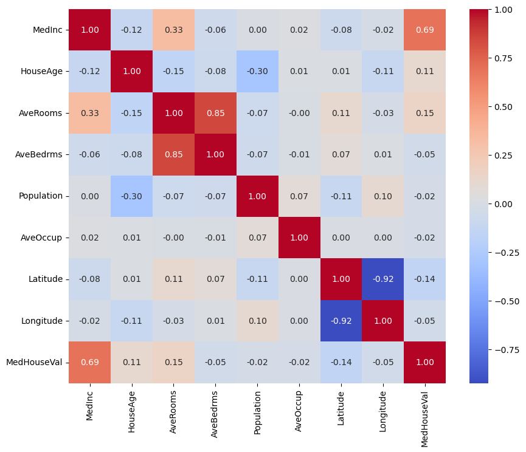

```python
# Correlation matrix to see the correlation between variables
correlation_matrix = df.corr()
plt.figure(figsize=(10, 8))
sns.heatmap(correlation_matrix, annot=True, cmap='coolwarm', fmt=".2f")
plt.show()
```

Our target variable hovewer has a huge number of "outliers" (tho in this case i wouldn't call them that since there are so many of them), we cannot drop all of these observations, and can only hope that the longitude and latitude variables will help us in these cases.

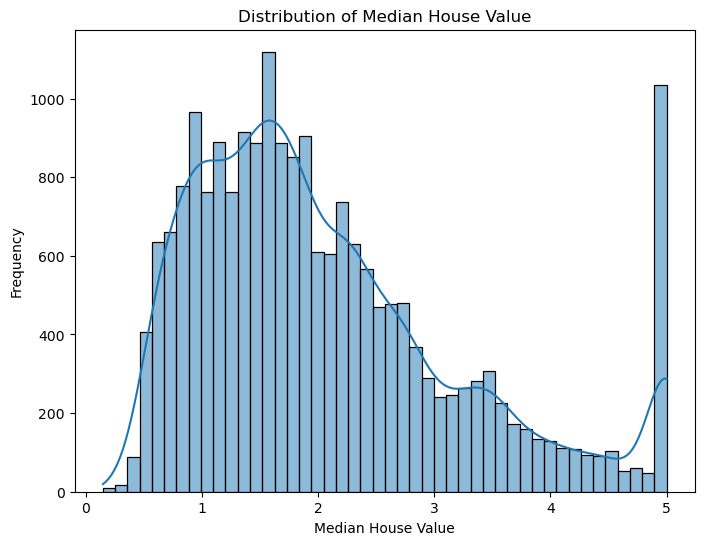

```python
plt.figure(figsize=(8, 6))
sns.histplot(target, kde=True) # kde:kernel density estimate to smooth the distribution
plt.title('Distribution of Median House Value')
plt.xlabel('Median House Value')
plt.ylabel('Frequency')
plt.show()
```

I created another boxplot to emphasize the severity of the outlier problem.

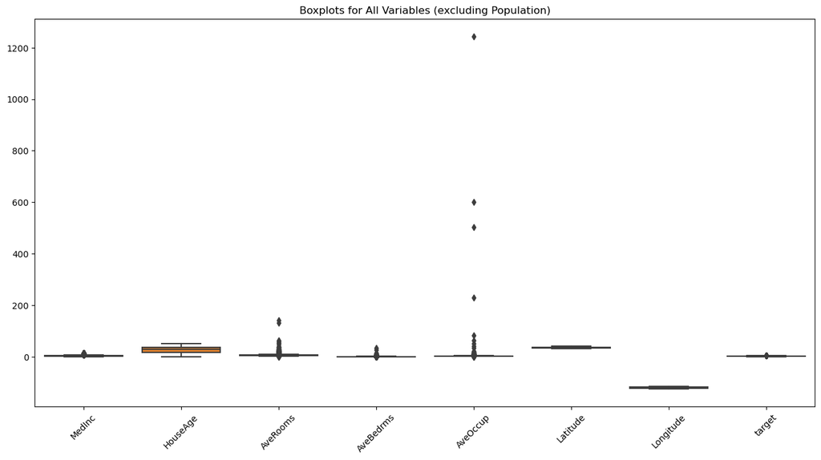

```python
import matplotlib.pyplot as plt
import seaborn as sns
from sklearn.datasets import fetch_california_housing

# Load the California Housing Prices dataset
california_housing = fetch_california_housing()
data = pd.DataFrame(data=np.c_[california_housing['data'], california_housing['target']],
                    columns=california_housing['feature_names'] + ['target'])

# Exclude the "Population" variable
selected_features = data.columns[data.columns != 'Population']

# Create boxplots for all variables except "Population"
plt.figure(figsize=(16, 8))
sns.boxplot(data=data[selected_features])
plt.title('Boxplots for All Variables (excluding Population)')
plt.xticks(rotation=45)  # Rotate x-axis labels for better readability
plt.show()
```

And another after the removal of a few outliers.

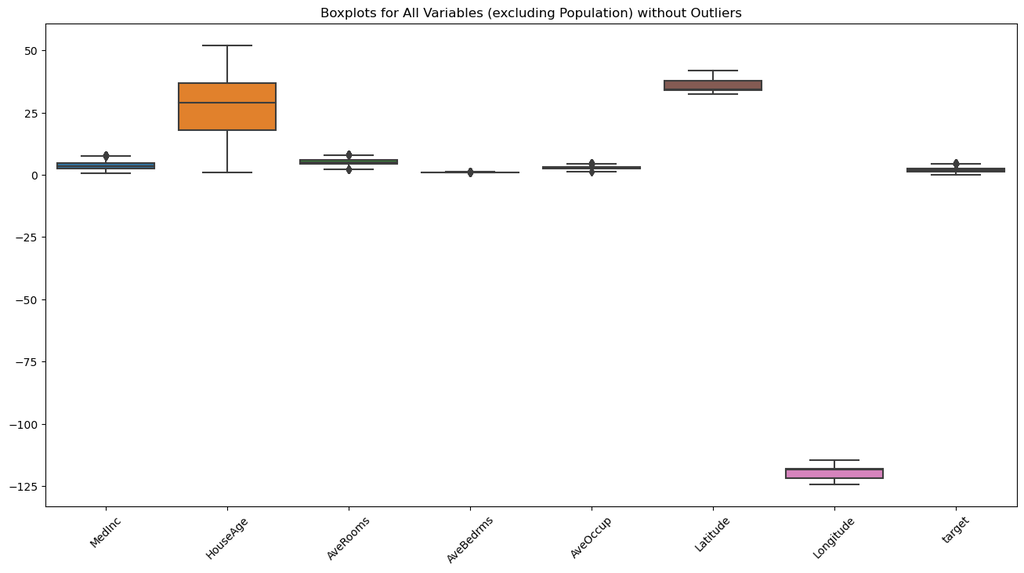

```python
california_housing = fetch_california_housing()
data = pd.DataFrame(data=np.c_[california_housing['data'], california_housing['target']],
                    columns=california_housing['feature_names'] + ['target'])

# Function to remove outliers using IQR method for all columns except 'Population'
def remove_outliers_iqr(df):
    selected_features = df.columns[df.columns != 'Population']
    for column in selected_features:
        Q1 = df[column].quantile(0.25)
        Q3 = df[column].quantile(0.75)
        IQR = Q3 - Q1
        lower_bound = Q1 - 1.5 * IQR
        upper_bound = Q3 + 1.5 * IQR
        df = df[(df[column] >= lower_bound) & (df[column] <= upper_bound)]
    return df

# Remove outliers from the DataFrame
df = remove_outliers_iqr(data)

# Create boxplots for all variables except "Population" after removing outliers
plt.figure(figsize=(16, 8))
sns.boxplot(data=df[selected_features])  # Specify the DataFrame and selected features here
plt.title('Boxplots for All Variables (excluding Population) without Outliers')
plt.xticks(rotation=45)  # Rotate x-axis labels for better readability
plt.show()
```

Next, I took a look at whether the data set has any missing values or not. It does not (hurray), thus we do not have to deal with them.

```python
missing_values = df.isnull().sum();
missing_values
```

```
MedInc         0
HouseAge       0
AveRooms       0
AveBedrms      0
Population     0
AveOccup       0
Latitude       0
Longitude      0
MedHouseVal    0
dtype: int64
```

I also separated the features and the target variable, and then standardized and scaled them, since their measurements differ quite a lot. I then split them into testing and training data sets to learn our models on.

```python
# Separating features and target
features = df.drop('MedHouseVal', axis=1);
target = df['MedHouseVal'];

# Normalizing/Standardizing features
scaler = StandardScaler();
scaled_features = scaler.fit_transform(features);
scaled_features_df = pd.DataFrame(scaled_features, columns=features.columns)
```

```python
scaler = StandardScaler()
scaled_features = scaler.fit_transform(features)
scaled_features_df = pd.DataFrame(scaled_features, columns=features.columns)
```

```python
X_train, X_test, y_train, y_test = train_test_split(scaled_features_df, target, test_size=0.2, random_state=42)
```

### 2. Spline regression

Now that we took the necessary preparatory steps, let's create a split regression. Here I used the provided code, changed the random state and played around with the degrees of freedom.

```
Best RMSE: 0.6754719831154479 at degree_of_freedom = 5
Best R2: 0.6695040338800262 at degree_of_freedom = 5
```

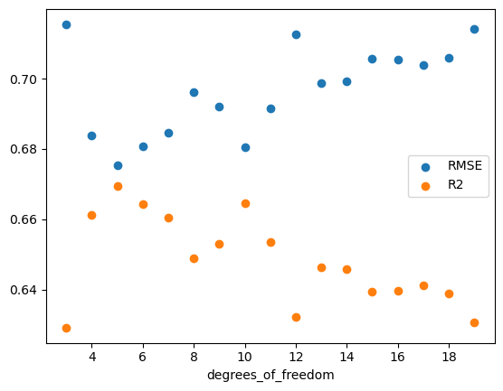

```python
import numpy as np
import pandas as pd
import matplotlib.pyplot as plt
from sklearn.model_selection import train_test_split
from sklearn.linear_model import LinearRegression
from sklearn.metrics import mean_squared_error, r2_score
from patsy import dmatrix
from patsy import dmatrix
import numpy as np
import matplotlib.pyplot as plt
from sklearn.model_selection import train_test_split
from sklearn.linear_model import LinearRegression
from sklearn.metrics import mean_squared_error, r2_score

# Regression with Splines
# Splitting the dataset into training and testing sets
X_train, X_test, y_train, y_test = train_test_split(scaled_features_df, target, test_size=0.2, random_state=40)

feature_names = scaled_features_df.columns

# Experimenting with different degrees of freedom for the spline model
degrees_of_freedom = np.arange(3, 20)
rmse = []
r2 = []

for df in degrees_of_freedom:
    formula = ' + '.join([f"cr({feature}, df="+str(df)+")" for feature in feature_names])

    transformed_X_train = dmatrix(formula, data=X_train, return_type='dataframe')
    transformed_X_test = dmatrix(formula, data=X_test, return_type='dataframe')

    # Fit the model
    model = LinearRegression()
    model.fit(transformed_X_train, y_train)

    # Predict on the test set
    y_pred = model.predict(transformed_X_test)

    # Evaluate the model
    rmse_val = np.sqrt(mean_squared_error(y_test, y_pred))
    r2_val = r2_score(y_test, y_pred)

    rmse.append(rmse_val)
    r2.append(r2_val)

# Find the best model parameters
best_rmse_index = np.argmin(rmse)
best_r2_index = np.argmax(r2)

best_rmse_degree = degrees_of_freedom[best_rmse_index]
best_r2_degree = degrees_of_freedom[best_r2_index]

print(f"Best RMSE: {rmse[best_rmse_index]} at degree_of_freedom = {best_rmse_degree}")
print(f"Best R2: {r2[best_r2_index]} at degree_of_freedom = {best_r2_degree}")

# Plotting
plt.scatter(degrees_of_freedom, rmse)
plt.scatter(degrees_of_freedom, r2)
plt.xlabel('degrees_of_freedom')
plt.legend(['RMSE', 'R2'])
plt.show()
```

```
Best RMSE: 0.6754719831154479 at degree_of_freedom = 5
Best R2: 0.6695040338800262 at degree_of_freedom = 5
```

[figure not shown]

```python
import numpy as np
import pandas as pd
import matplotlib.pyplot as plt
from sklearn.model_selection import train_test_split
from sklearn.linear_model import LinearRegression
from sklearn.metrics import mean_squared_error, r2_score
from patsy import dmatrix

# Assuming you have already defined your data, features, and target variables
# ...

# Regression with Splines
# Splitting the dataset into training and testing sets
X_train, X_test, y_train, y_test = train_test_split(scaled_features_df, target, test_size=0.2, random_state=40)

feature_names = scaled_features_df.columns

# Experimenting with different degrees of freedom for the spline model
degrees_of_freedom = np.arange(3, 20)
rmse = []
r2 = []

for df in degrees_of_freedom:
    formula = ' + '.join([f"cr({feature}, df="+str(df)+")" for feature in feature_names])

    transformed_X_train = dmatrix(formula, data=X_train, return_type='dataframe')
    transformed_X_test = dmatrix(formula, data=X_test, return_type='dataframe')

    # Fit the model
    model = LinearRegression()
    model.fit(transformed_X_train, y_train)

    # Predict on the test set
    y_pred = model.predict(transformed_X_test)

    # Evaluate the model
    rmse_val = np.sqrt(mean_squared_error(y_test, y_pred))
    r2_val = r2_score(y_test, y_pred)

    rmse.append(rmse_val)
    r2.append(r2_val)

# Find the best model parameters
best_rmse_index = np.argmin(rmse)
best_r2_index = np.argmax(r2)

best_rmse_degree = degrees_of_freedom[best_rmse_index]
best_r2_degree = degrees_of_freedom[best_r2_index]

print(f"Best RMSE: {rmse[best_rmse_index]} at degree_of_freedom = {best_rmse_degree}")
print(f"Best R2: {r2[best_r2_index]} at degree_of_freedom = {best_r2_degree}")

# Get the best formula
best_formula = ' + '.join([f"cr({feature}, df="+str(best_r2_degree)+")" for feature in feature_names])

# Transform the training and test data with the best formula
best_transformed_X_train = dmatrix(best_formula, data=X_train, return_type='dataframe')
best_transformed_X_test = dmatrix(best_formula, data=X_test, return_type='dataframe')

# Fit the best model
best_model = LinearRegression()
best_model.fit(best_transformed_X_train, y_train)

# Predict on the test set using the best model
best_y_pred = best_model.predict(best_transformed_X_test)

# Plotting the predicted vs. actual values
plt.figure(figsize=(12, 6))
plt.scatter(y_test, best_y_pred)
plt.plot([min(y_test), max(y_test)], [min(y_test), max(y_test)], linestyle='--', color='red', linewidth=2)
plt.title('Predicted vs. Actual Values for the Best Spline model')
plt.xlabel('Actual Values')
plt.ylabel('Predicted Values')
plt.show()
```

Our goal is to minimize RMSE and maximize R2. From the plot one can easily conclude that a simple cubice spline wouldn't be the wisest choice. The shape of both RMSE and R2 seems to correspond with common sense. In the beggining, as we increase the number of knots our accuracy sharply increases, since our bias drops, but as we increase the degrees of freedom further the models accuracy declines as we run into the problem of overfitting. The best option seems to be at 5 degrees of freedom, with RMSE 0.68 and an R squared of 0.67.

### 3. Regression with ensemble Decision Trees

As I promised, I also created free decision tree models as well. Again I changed the random state and given more depth, learning rate and n_estimator options for the possible models. It seems like my hunch about the lack of proper training data for the most expensive houses was right, as all of the three models strugle to accurately predict the characteristics of the most expensive houses. In a real life scenario I would advise to create a new factor variable, specifically for the two big cities. Other than that the models seem to work just fine, with high R squared values, to which I will return in the next part.

```
Model:   Random Forest
{'n_estimators': [100, 200, 300, 400, 500, 600], 'max_depth': [5, 10, 15, 20, 25]}
```

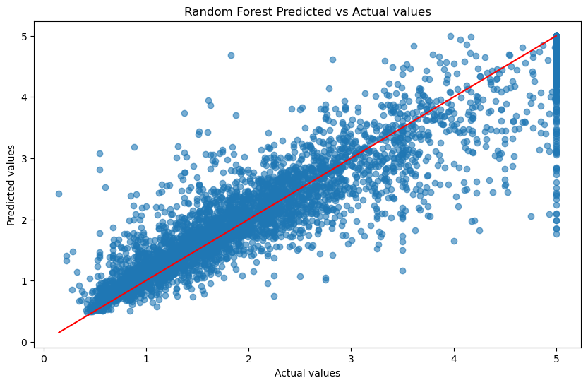

```
Model:   AdaBoost
{'n_estimators': [50, 100, 200, 300, 400, 500, 600], 'learning_rate': [0.001, 0.01, 0.1, 0.2, 0.5]}
```

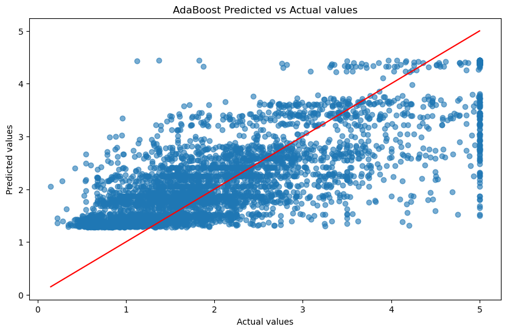

```
Model:   Gradient Boosting
{'n_estimators': [50, 100, 200, 300, 400, 500, 600], 'learning_rate': [0.001, 0.01, 0.1, 0.2, 0.5], 'max_depth': [3, 5, 7, 9, 11]}
```

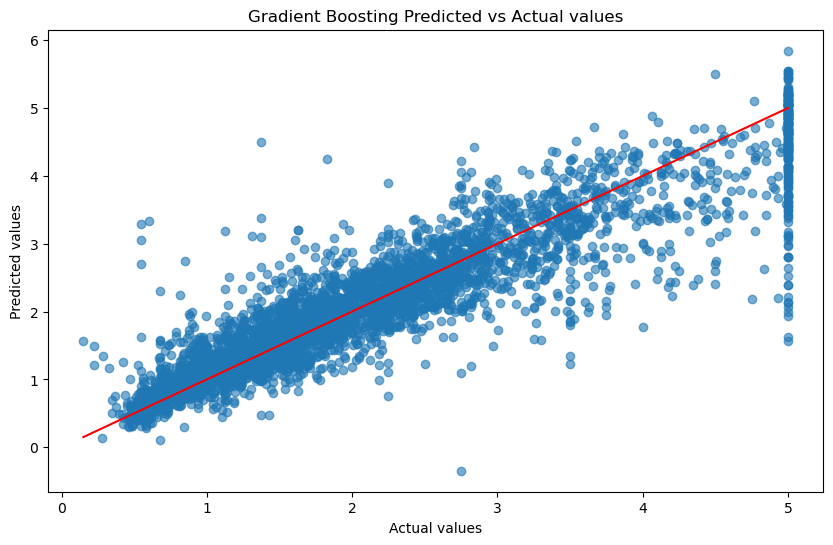

```
{'Random Forest': {'RMSE': 0.5208880656031016, 'R2': 0.8034648218294115, 'Best Params': {'n_estimators': 500, 'max_depth': 20}}, 'AdaBoost': {'RMSE': 0.7706906030810974, 'R2': 0.5697591826367914, 'Best Params': {'n_estimators': 300, 'learning_rate': 0.01}}, 'Gradient Boosting': {'RMSE': 0.4885653140…
Wall time: 16min 39s
```

```python
%%time
from sklearn.ensemble import RandomForestRegressor, AdaBoostRegressor, GradientBoostingRegressor
from sklearn.model_selection import RandomizedSearchCV
from sklearn.metrics import mean_squared_error, r2_score
import matplotlib.pyplot as plt
import numpy as np

# Models to be used
models = {
    "Random Forest": RandomForestRegressor(random_state=40),
    "AdaBoost": AdaBoostRegressor(random_state=40),
    "Gradient Boosting": GradientBoostingRegressor(random_state=40)
}

# Hyperparameters for tuning
parameters = {
    "Random Forest": {'n_estimators': [100, 200, 300, 400, 500, 600], 'max_depth': [5, 10, 15, 20, 25]},
    "AdaBoost": {'n_estimators': [50, 100, 200, 300, 400, 500, 600], 'learning_rate': [0.001, 0.01, 0.1, 0.2, 0.5]},
    "Gradient Boosting": {'n_estimators': [50, 100, 200, 300, 400, 500, 600], 'learning_rate': [0.001, 0.01, 0.1, 0.2, 0.5], 'max_depth': [3, 5, 7, 9, 11]}
}

# Storing model performance
model_performance = {}

# Tuning hyperparameters and evaluating each model
for model_name in models:
    print('Model:  ', model_name)
    model = models[model_name]
    params = parameters[model_name]
    print(params)

    # Using RandomizedSearchCV for hyperparameter tuning
    param_search = RandomizedSearchCV(estimator=model, param_distributions=params, cv=3, scoring='neg_mean_squared_error')
    param_search.fit(X_train, y_train)

    # Best model
    best_model = param_search.best_estimator_

    # Predict on test set
    y_pred = best_model.predict(X_test)

    # Evaluate the model
    rmse = np.sqrt(mean_squared_error(y_test, y_pred))
    r2 = r2_score(y_test, y_pred)

    # Store results
    model_performance[model_name] = {'RMSE': rmse, 'R2': r2, 'Best Params': param_search.best_params_}

    # Visualization: Predicted vs Actual values
    plt.figure(figsize=(10, 6))
    plt.scatter(y_test, y_pred, alpha=0.6)
    plt.xlabel('Actual values')
    plt.ylabel('Predicted values')
    plt.title(f'{model_name} Predicted vs Actual values')
    plt.plot([min(y_test), max(y_test)], [min(y_test), max(y_test)], color='red')  # Diagonal line
    plt.show()

# Output model performance
print(model_performance)
```

### 4. Model Comparison and analysis

Strictly speaking the best method seems to be Gradient Boosting. The random forest is a close second, hovewer I would argue that since it uses just as many "trees" and has such a huge depth I would consider Gradient boosting the absolute winner. In the past two subchapters I already provided visual comparisons of the fitted and actual values for the models, and the same conclusions can be drawn from them as well (although with less certainty due to their convoluted nature).

The hyperparameters play a huge role in model selection. They are external configuration settings, set prior to the training process, used to control the behavior of machine learning models and have a significant effect on performance. With them we can also control the bias-variance trade off, whether we want a more general model with more bias, or a nuanced one which fits the training data perfectly, based on our prior knowledge on the underlying data.

Based on our correlation analysis and the coefficients the most important features in determining a neighbourhoods median house values are the median household income and the average number of rooms.

| Model | RMSE | R2 | Best parameters |
| --- | --- | --- | --- |
| Spline regression | 0.68 | 0.67 | degree of freedom = 5 |
| Random Forest | 0.52 | 0.80 | n = 500; depth = 20 |
| Adaboost | 0.77 | 0.57 | n = 300; le.rate = 0.01 |
| Gradient Boosting | 0.49 | 0.83 | n = 500; depth = 3; le.rate = 0.2 |

```python
from sklearn import datasets
from sklearn.model_selection import train_test_split
from sklearn.preprocessing import StandardScaler
from sklearn.svm import SVC
from sklearn.metrics import classification_report, roc_auc_score
import matplotlib.pyplot as plt
import seaborn as sns
import pandas as pd
import numpy as np

import warnings
# Settings the warnings to be ignored
warnings.filterwarnings('ignore')
```

# II. Classification

## Tasks

### 1. Data Exploration and Preprocessing

In the first part, as before I will conduct an exploratory data analysis. If we take a look at the first five values of the dataset we can see that we will need some standardization in this instance as well.

```python
# Load the dataset
data = datasets.load_breast_cancer()
X = data.data
y = data.target

# Convert to DataFrame for easier visualization
df = pd.DataFrame(X, columns=data.feature_names)
df['target'] = y
df.head
```

```
<bound method NDFrame.head of      mean radius  mean texture  mean perimeter  mean area  mean smoothness  \
0          17.99         10.38          122.80     1001.0          0.11840
1          20.57         17.77          132.90     1326.0          0.08474
2          19.69         21.25          130.00     1203.0          0.10960
3          11.42         20.38           77.58      386.1          0.14250
4          20.29         14.34          135.10     1297.0          0.10030
..           ...           ...             ...        ...              ...
564        21.56         22.39          142.00     1479.0          0.11100
565        20.13         28.25          131.20     1261.0          0.09780
566        16.60         28.08          108.30      858.1          0.08455
567        20.60         29.33          140.10     1265.0          0.11780
568         7.76         24.54           47.92      181.0          0.05263

     mean compactness  mean concavity  mean concave points  mean symmetry  \
0             0.27760         0.30010              0.14710         0.2419
```

[output cut: 51 more lines]

According to the description there are some outliers present in this dataset as well, but they do not seem as big of a problem as in the previous dataset.

```python
print(df.describe())
```

```
       mean radius  mean texture  mean perimeter    mean area  \
count   569.000000    569.000000      569.000000   569.000000
mean     14.127292     19.289649       91.969033   654.889104
std       3.524049      4.301036       24.298981   351.914129
min       6.981000      9.710000       43.790000   143.500000
25%      11.700000     16.170000       75.170000   420.300000
50%      13.370000     18.840000       86.240000   551.100000
75%      15.780000     21.800000      104.100000   782.700000
max      28.110000     39.280000      188.500000  2501.000000

       mean smoothness  mean compactness  mean concavity  mean concave points  \
count       569.000000        569.000000      569.000000           569.000000
mean          0.096360          0.104341        0.088799             0.048919
std           0.014064          0.052813        0.079720             0.038803
min           0.052630          0.019380        0.000000             0.000000
25%           0.086370          0.064920        0.029560             0.020310
50%           0.095870          0.092630        0.061540             0.033500
75%           0.105300          0.130400        0.130700             0.074000
max           0.163400          0.345400        0.426800             0.201200

       mean symmetry  mean fractal dimension  ...  worst texture  \
count     569.000000              569.000000  ...     569.000000
mean        0.181162                0.062798  ...      25.677223
std         0.027414                0.007060  ...       6.146258
min         0.106000                0.049960  ...      12.020000
25%         0.161900                0.057700  ...      21.080000
50%         0.179200                0.061540  ...      25.410000
75%         0.195700                0.066120  ...      29.720000
max         0.304000                0.097440  ...      49.540000

       worst perimeter   worst area  worst smoothness  worst compactness  \
count       569.000000   569.000000        569.000000         569.000000
mean        107.261213   880.583128          0.132369           0.254265
std          33.602542   569.356993          0.022832           0.157336
min          50.410000   185.200000          0.071170           0.027290
25%          84.110000   515.300000          0.116600           0.147200
50%          97.660000   686.500000          0.131300           0.211900
75%         125.400000  1084.000000          0.146000           0.339100
max         251.200000  4254.000000          0.222600           1.058000

       worst concavity  worst concave points  worst symmetry  \
count       569.000000            569.000000      569.000000
mean          0.272188              0.114606        0.290076
std           0.208624              0.065732        0.061867
min           0.000000              0.000000        0.156500
25%           0.114500              0.064930        0.250400
50%           0.226700              0.099930        0.282200
75%           0.382900              0.161400        0.317900
max           1.252000              0.291000        0.663800

       worst fractal dimension      target
count               569.000000  569.000000
mean                  0.083946    0.627417
std                   0.018061    0.483918
min                   0.055040    0.000000
25%                   0.071460    0.000000
50%                   0.080040    1.000000
75%                   0.092080    1.000000
max                   0.207500    1.000000

[8 rows x 31 columns]
```

Using this simple plot we can see that there are 212 observations where the tumour was found malignant and 357 observations in which they were found to be benign. I also scaled the variables before further procedures.

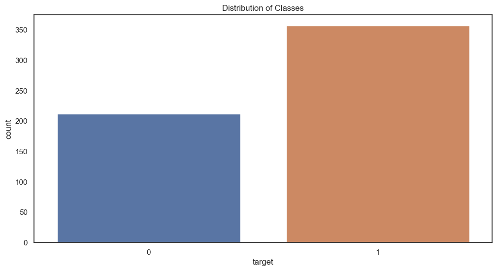

```python
# EDA: Visualizing the distribution of classes and features
plt.figure(figsize=(12, 6))
sns.countplot(x='target', data=df)
plt.title('Distribution of Classes')
plt.show()
```

```python
# Preprocessing: Scaling features
scaler = StandardScaler()
X_scaled = scaler.fit_transform(X)

x_df =  pd.DataFrame(X_scaled, columns=data.feature_names)
```

As we have seen from the description there are outliers in the dataset, but if we take a look at the boxplot we can see that there are only a few of them. Since we do not have that many observations in this case I will not exclude them from our investigation.

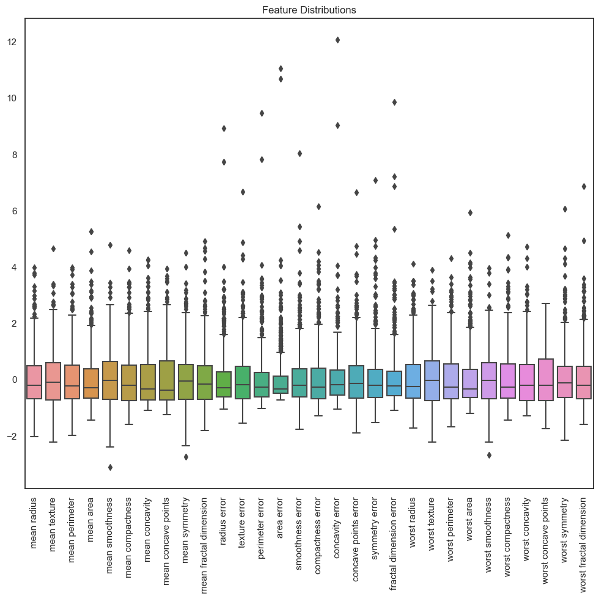

```python
plt.figure(figsize=(12, 10))
sns.boxplot(data=x_df)  # Specify the 'data' parameter
plt.xticks(rotation=90)
plt.title('Feature Distributions')
plt.show()

# Train-test split
X_train, X_test, y_train, y_test = train_test_split(X_scaled, y, test_size=0.3, random_state=42)
```

If we take a look at the correlation matrix we can see that quite a few variables seem to be connected to each other. As a summary it can be said that while the individual characteristics are have varying relationships with each other if they have any corellation with whether the tumor is cancerous or not it is negative.

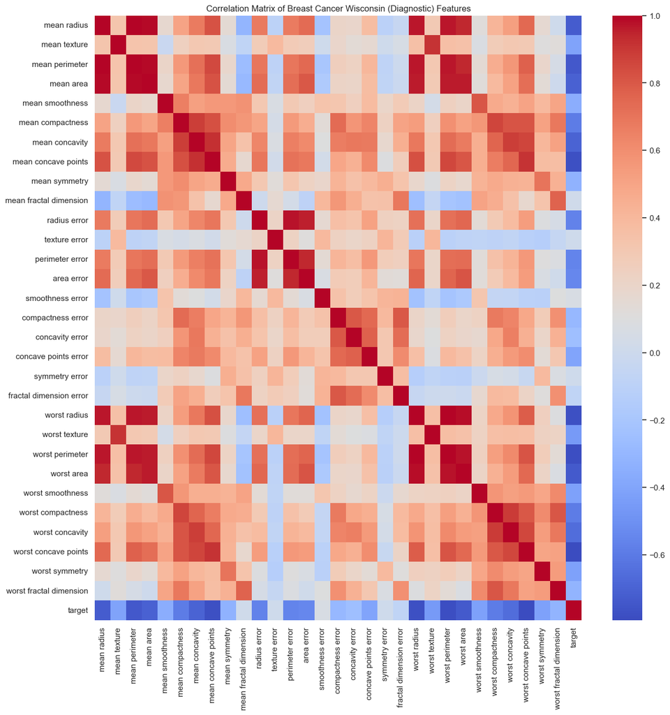

```python
# Perform correlation analysis
correlation_matrix = df.corr()

# Plotting the correlation matrix
plt.figure(figsize=(15, 15))
sns.heatmap(correlation_matrix, annot=False, cmap='coolwarm')
plt.title('Correlation Matrix of Breast Cancer Wisconsin (Diagnostic) Features')
plt.show()
```

It seems like there are some high correlations between features as well which could lead to multicollinearity in our models (though we shouldn't really care about that in our case). Most variables seem to have a right skewed distribution, with a mean of zero.

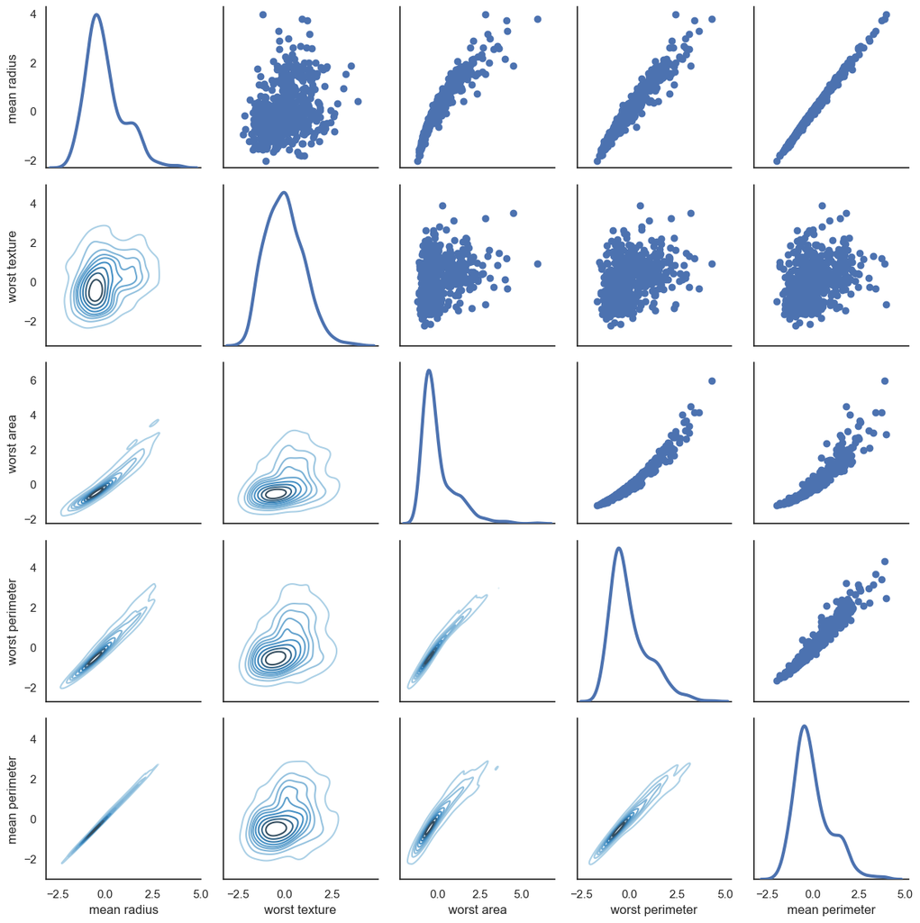

```python
sns.set(style="white")
dd = x_df.loc[:,['mean radius','worst texture','worst area', 'worst perimeter', 'mean perimeter']]
g = sns.PairGrid(dd, diag_sharey=False)
g.map_lower(sns.kdeplot, cmap="Blues_d")
g.map_upper(plt.scatter)
g.map_diag(sns.kdeplot, lw=3)
```

### 2. Classification with Support Vector Machines (SVM)

First I am going to create a support vector machine for our classification problem. I tweeked the algorithm from the example code to find the perfect regularization parameter for the best model. In this case it is 2 which I would consider a rather small C, resulting in a more flexible margin.

```python
# Classification with SVM
best_model = None
best_accuracy = 0

svm_results = {}

for i in range(1, 6):
    for kernel in ['linear', 'poly', 'rbf']:
        svm = SVC(kernel=kernel, C=i)
        svm.fit(X_train, y_train)
        y_pred = svm.predict(X_test)
        accuracy = svm.score(X_test, y_test)
        precision, recall, f1, _ = classification_report(y_test, y_pred, output_dict=True)['weighted avg'].values()
        roc_auc = roc_auc_score(y_test, y_pred)

        svm_results[(i, kernel)] = {
            'Accuracy': accuracy,
            'Precision': precision,
            'Recall': recall,
            'F1 Score': f1,
            'ROC-AUC': roc_auc
        }

        # Update best_model if current model has higher accuracy
        if accuracy > best_accuracy:
            best_accuracy = accuracy
            best_model = {
                'C': i,
                'Kernel': kernel,
                'Accuracy': accuracy,
                'Precision': precision,
                'Recall': recall,
                'F1 Score': f1,
                'ROC-AUC': roc_auc
            }

# Display results
#pd.DataFrame(svm_results)
#print("Best Model:")
print(best_model)
```

```
{'C': 2, 'Kernel': 'rbf', 'Accuracy': 0.9824561403508771, 'Precision': 0.9824691204186851, 'Recall': 0.9824561403508771, 'F1 Score': 0.9824263885520251, 'ROC-AUC': 0.9794973544973544}
```

The best model according to all measures is the radial basis function, but the linear model is a close second. They all have very high accuracy meaning that they predict the right categories based on features in a high number of cases.

```python
# Classification with SVM
svm_results = {}

for kernel in ['linear', 'poly', 'rbf']:
    svm = SVC(kernel=kernel, C=2.0)
    svm.fit(X_train, y_train)
    y_pred = svm.predict(X_test)
    accuracy = svm.score(X_test, y_test)
    precision, recall, f1, _ = classification_report(y_test, y_pred, output_dict=True)['weighted avg'].values()
    roc_auc = roc_auc_score(y_test, y_pred)

    svm_results[kernel] = {
        'Accuracy': accuracy,
        'Precision': precision,
        'Recall': recall,
        'F1 Score': f1,
        'ROC-AUC': roc_auc
    }

# Display results
pd.DataFrame(svm_results)
```

|  | linear | poly | rbf |
| --- | --- | --- | --- |
| Accuracy | 0.976608 | 0.906433 | 0.982456 |
| Precision | 0.977038 | 0.918506 | 0.982469 |
| Recall | 0.976608 | 0.906433 | 0.982456 |
| F1 Score | 0.976682 | 0.902854 | 0.982426 |
| ROC-AUC | 0.978175 | 0.873016 | 0.979497 |

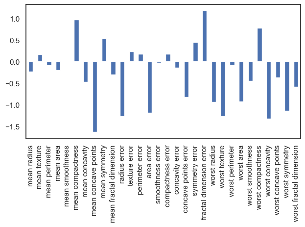

```python
# Only for linear kernel because for others
# data is transformed by kernel method to another space.

def f_importances(coef, names):
    imp = coef
    imp,names = zip(*sorted(zip(imp,names)))
    plt.barh(range(len(names)), imp, align='center')
    plt.yticks(range(len(names)), names)
    plt.show()

svm = SVC(kernel='linear', C=2.0)
svm.fit(X_train, y_train)

importances = pd.Series(svm.coef_[0], index=data.feature_names)

fig, ax = plt.subplots()
importances.plot.bar( ax=ax)
fig.tight_layout()
```

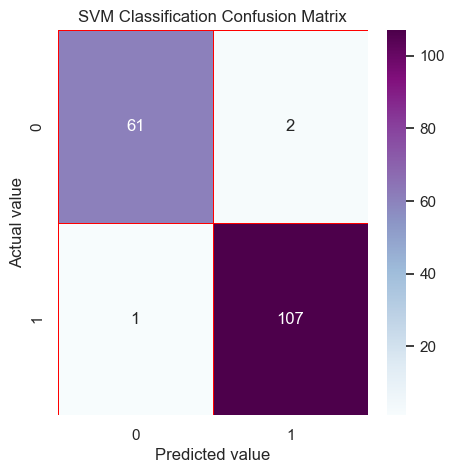

```python
# The confusion matrix
from sklearn.metrics import confusion_matrix
svmcla_cm = confusion_matrix(y_test, y_pred)
f, ax = plt.subplots(figsize=(5,5))
sns.heatmap(svmcla_cm, annot=True, linewidth=0.7, linecolor='red', fmt='g', ax=ax, cmap="BuPu")
plt.title('SVM Classification Confusion Matrix')
plt.xlabel('Predicted value')
plt.ylabel('Actual value')
plt.show()
```

### 3. Classification with Advanced Decision Trees

Since I loved decision trees in the previous part as well, why not apply them for this classification problem as well? I used the random forest and gradient boosting methods to create two models to solve this problem. Random forest seems to provide better results in this case.

```python
from sklearn.ensemble import RandomForestClassifier, GradientBoostingClassifier
from sklearn.model_selection import GridSearchCV

from sklearn.metrics import accuracy_score, precision_score, recall_score, f1_score

# Classification with Advanced Decision Trees
# Random Forest
rf = RandomForestClassifier(random_state=42)
rf_params = {
    'n_estimators': [100, 200],
    'max_depth': [5, 10, None]
}
rf_grid = GridSearchCV(rf, rf_params, cv=5)
rf_grid.fit(X_train, y_train)
rf_best = rf_grid.best_estimator_
y_pred_rf = rf_best.predict(X_test)

# Gradient Boosting
gb = GradientBoostingClassifier(random_state=42)
gb_params = {
    'n_estimators': [100, 200],
    'learning_rate': [0.01, 0.1, 0.2],
    'max_depth': [3, 5]
}
gb_grid = GridSearchCV(gb, gb_params, cv=5)
gb_grid.fit(X_train, y_train)
gb_best = gb_grid.best_estimator_
y_pred_gb = gb_best.predict(X_test)

# Metrics for Random Forest and Gradient Boosting
rf_metrics = {
    'Accuracy': accuracy_score(y_test, y_pred_rf),
    'Precision': precision_score(y_test, y_pred_rf),
    'Recall': recall_score(y_test, y_pred_rf),
    'F1 Score': f1_score(y_test, y_pred_rf),
    'ROC-AUC': roc_auc_score(y_test, y_pred_rf)
}

gb_metrics = {
    'Accuracy': accuracy_score(y_test, y_pred_gb),
    'Precision': precision_score(y_test, y_pred_gb),
    'Recall': recall_score(y_test, y_pred_gb),
    'F1 Score': f1_score(y_test, y_pred_gb),
    'ROC-AUC': roc_auc_score(y_test, y_pred_gb)
}

results = {'Random Forest': rf_metrics, 'Gradient Boosting': gb_metrics}
pd.DataFrame(results)
```

|  | Random Forest | Gradient Boosting |
| --- | --- | --- |
| Accuracy | 0.970760 | 0.959064 |
| Precision | 0.963964 | 0.963303 |
| Recall | 0.990741 | 0.972222 |
| F1 Score | 0.977169 | 0.967742 |
| ROC-AUC | 0.963624 | 0.954365 |

If we take a look at the confusion matrix it is salient that it performs a bit worse than SVM did. I have a hunch that this lonely falsely categoriyed person is the same, and it's existence is due to one or multiple outlier variables.

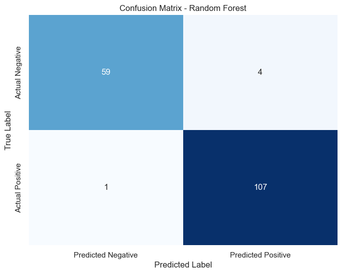

```python
conf_matrix_rf = confusion_matrix(y_test, y_pred_rf)

# Plot the confusion matrix
plt.figure(figsize=(8, 6))
sns.heatmap(conf_matrix_rf, annot=True, fmt='d', cmap='Blues', cbar=False,
            xticklabels=['Predicted Negative', 'Predicted Positive'],
            yticklabels=['Actual Negative', 'Actual Positive'])
plt.title('Confusion Matrix - Random Forest')
plt.xlabel('Predicted Label')
plt.ylabel('True Label')
plt.show()
```

We can see that the random forest also identified mean concave points as a highly significant parameter. Hovewer it pinpointed oerimeter and area as well which SVM didn't. This is most likely due to the random nature of the algorithm and due to the fact that there is, as I mentioned before, high multivariation in the dataset.

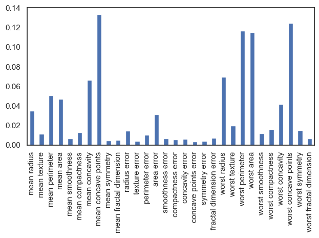

```python
importances = pd.Series(rf_best.feature_importances_, index=data.feature_names)

fig, ax = plt.subplots()
importances.plot.bar( ax=ax)
fig.tight_layout()
```

### 4. Classification with Generalized Additive Models (GAMs)

For my final model I will use a better version of GLM, I will utilize a generalized additive model. I used both smooth functions (s) and tensor products (te)l to capture potential non-linear relationships and interactions, and chosen the number of splines manually. To get binary outcomes I used a simple logistic link function.

```python
# https://pygam.readthedocs.io/en/latest/api/api.html#generalized-additive-model-classes
from pygam import LogisticGAM, LinearGAM, s,l, te, GAM, terms
```

```python
# Classification with Generalized Additive Models (GAMs)
gam = LogisticGAM(s(0, n_splines=15) + s(1) + s(2) + s(6)+ s(8)+ te(5,8, n_splines =[13,13])  ).fit(X_train, y_train)

y_pred_gam = gam.predict(X_test)

# Metrics for GAM
gam_metrics = {
    'Accuracy': accuracy_score(y_test, y_pred_gam),
    'Precision': precision_score(y_test, y_pred_gam),
    'Recall': recall_score(y_test, y_pred_gam),
    'F1 Score': f1_score(y_test, y_pred_gam),
    'ROC-AUC': roc_auc_score(y_test, y_pred_gam)
}
pd.DataFrame({'GAM':gam_metrics})
```

|  | GAM |
| --- | --- |
| Accuracy | 0.970760 |
| F1 Score | 0.977169 |
| Precision | 0.963964 |
| ROC-AUC | 0.963624 |
| Recall | 0.990741 |

This model seems to be highly accurate as well, an par with the random forest, presumably making the exact same mistake.

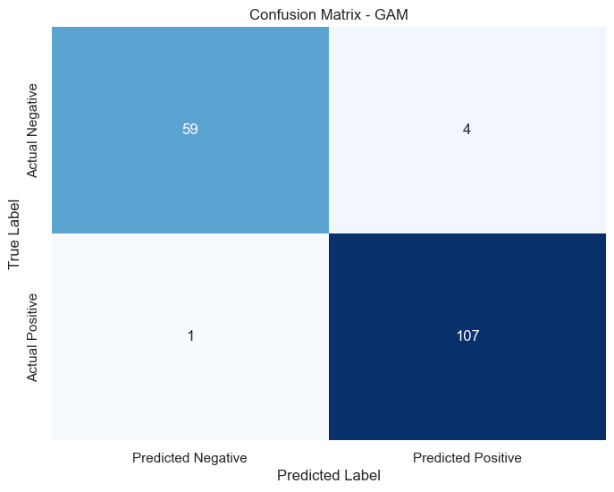

```python
conf_matrix_gam = confusion_matrix(y_test, y_pred_gam)

# Plot the confusion matrix
plt.figure(figsize=(8, 6))
sns.heatmap(conf_matrix_gam, annot=True, fmt='d', cmap='Blues', cbar=False,
            xticklabels=['Predicted Negative', 'Predicted Positive'],
            yticklabels=['Actual Negative', 'Actual Positive'])
plt.title('Confusion Matrix - GAM')
plt.xlabel('Predicted Label')
plt.ylabel('True Label')
plt.show()
```

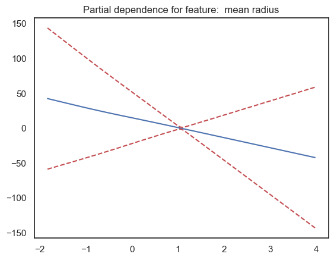

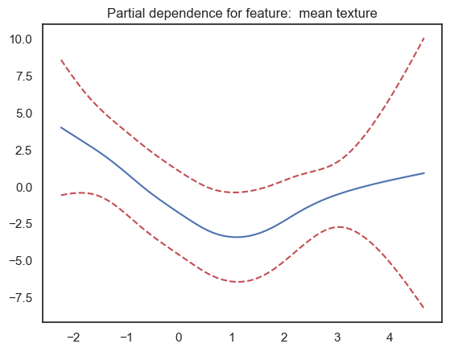

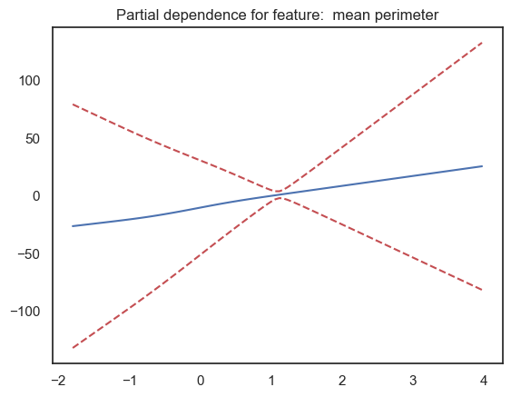

[figure not shown]

[figure not shown]

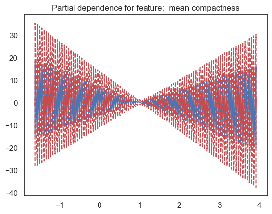

```python
f = data.feature_names

for i, term in enumerate(gam.terms):
    if term.isintercept:
        continue
    XX = gam.generate_X_grid(term=i)
    pdep, confi = gam.partial_dependence(term=i, X=XX, width=0.95)
    plt.figure()
    plt.plot(XX[:, i], pdep)
    plt.plot(XX[:, i], confi, c='r', ls='--')
    plt.title(f'Partial dependence for feature:  {f[i]}')
    plt.show()
```

### 5. Model Comparison, Analysis and conclusion

Let's compare the models according to their most important measures. Looking at their ROC curves (for some reason I was unable to plot random forest and GAM, even chatgpt didn't prove to be useful) it is quite hard to tell the difference visually

```
Skipping Random Forest as it doesn't provide decision function.
Skipping GAM as it doesn't provide decision function.
```

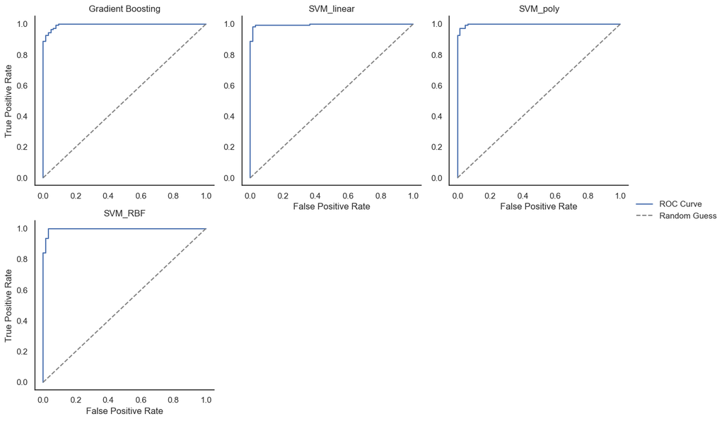

```python
from sklearn.metrics import roc_curve, auc


# Assuming you have SVM models for different kernels
svm_linear = SVC(kernel='linear', C=2.0, probability=True).fit(X_train, y_train)
svm_poly = SVC(kernel='poly', C=2.0, probability=True).fit(X_train, y_train)
svm_rbf = SVC(kernel='rbf', C=2.0, probability=True).fit(X_train, y_train)


# Classification models
classifiers = {
    'Random Forest': rf_best,
    'Gradient Boosting': gb_best,
    'SVM_linear': svm_linear,
    'SVM_poly': svm_poly,
    'SVM_RBF': svm_rbf,
    'GAM': gam
}

import seaborn as sns

# Create a dataframe to store ROC curve data
roc_data = {'fpr': [], 'tpr': [], 'Model': []}

# Plotting ROC curves for each model
plt.figure(figsize=(12, 8))

# Function to plot random guess line
def plot_random_guess(*args, **kwargs):
    plt.plot([0, 1], [0, 1], linestyle='--', color='grey', label='Random Guess')

for name, model in classifiers.items():
    if hasattr(model, "decision_function"):
        y_pred_scores = model.decision_function(X_test)
        if y_pred_scores.ndim > 1:
            y_pred_scores = y_pred_scores[:, 1]
        else:
            # If decision_function is 1-dimensional, consider it as the probability score
            y_pred_scores = y_pred_scores
    else:
        # If decision_function is not available, skip the model for ROC curve plotting
        print(f"Skipping {name} as it doesn't provide decision function.")
        continue

    fpr, tpr, _ = roc_curve(y_test, y_pred_scores)
    roc_auc = auc(fpr, tpr)

    # Store data for the FacetGrid
    roc_data['fpr'].extend(fpr)
    roc_data['tpr'].extend(tpr)
    roc_data['Model'].extend([name] * len(fpr))

# Create a FacetGrid
roc_df = pd.DataFrame(roc_data)
g = sns.FacetGrid(roc_df, col="Model", col_wrap=3, height=4, sharex=False, sharey=False)
g.map(plt.plot, "fpr", "tpr", label="ROC Curve")
g.map(plot_random_guess)
g.set_axis_labels("False Positive Rate", "True Positive Rate")
g.set_titles(col_template="{col_name}")
g.add_legend()

plt.show()
```

```python
# Combine results
results = {'Random Forest': rf_metrics,
           'Gradient Boosting': gb_metrics, 'SVM_linear':svm_results['linear'],
           'SVM_poly':svm_results['poly'],
           'SVM_RBF':svm_results['rbf'],'GAM': gam_metrics
          }
pd.DataFrame(results)
```

|  | Random Forest | Gradient Boosting | SVM_linear | SVM_poly | SVM_RBF | GAM |
| --- | --- | --- | --- | --- | --- | --- |
| Accuracy | 0.970760 | 0.959064 | 0.976608 | 0.906433 | 0.982456 | 0.970760 |
| Precision | 0.963964 | 0.963303 | 0.977038 | 0.918506 | 0.982469 | 0.963964 |
| Recall | 0.990741 | 0.972222 | 0.976608 | 0.906433 | 0.982456 | 0.990741 |
| F1 Score | 0.977169 | 0.967742 | 0.976682 | 0.902854 | 0.982426 | 0.977169 |
| ROC-AUC | 0.963624 | 0.954365 | 0.978175 | 0.873016 | 0.979497 | 0.963624 |